# Exploring the BRFSS data

## Setup

### Load packages

```r
library(ggplot2)
library(dplyr)
```

### Load data

```r
load("data/brfss2013.RData")
```

## Part 1: Data

The BRFSS project is a collection of surveys designed to measure behavioral risk factors for the non-institutionalized adult population (18 years of age and older) residing in the US.

**Sample** The data consists of 491775 observations and 330 variables.

```r
dim(brfss2013)
```

```
## [1] 491775    330
```

**Sampling** The data collection could be seen as two types of sampling: Stratified Sampling and Simple Random Sampling. It is stratified sampling because the sample in this survey is drawn from 50 different states in US which can be referred as different stratas in the stratified sampling. It is random sampling because the sample is genereated randomly from telephone and mobile phone interview with adults.

**Population** It can be assumed that the sample is representative of the population, given its large sample size and randomness in sampling.

**Observational vs Experiment**

This study is “observational” since the data is collected via telephone interviews where there is no direct interference.

**Association vs Casuality** Since it is an observational study, researchers can at best generalise associations between variables rather than prove causality. This is because no random assignment was made while conducting the study.

## Part 2: Research questions

In this research, we focus on the impact of educational levels on individual behaviors.

**Research quesion 1:** - educa: Education Level, categorical variable - genhlth: General Health, categorical variable

Does the educational level have any association with general health? Since the general health is the basic variable of this study, it is important to analyse the general association first before going through the more specific behaviors. The persons who have higher educational levels might be more or less responsible to keep themselves healthy.

**Research quesion 2:** - educa: Education Level, categorical variable - sex: Respondents Sex, categorical variable - alcday5: Days In Past 30 Had Alcoholic Beverage, continuous variable

Does the educational level have any association with the alcohol consumption? It is known that there is a positive assocation between education and alcohol consumption (http://journal.frontiersin.org/article/10.3389/fpubh.2016.00067/full). Nevertheless, we will look into this data to see if the positive assumption is still hold and how it is different between sexes.

**Research quesion 3:** - educa: Education Level, categorical variable - sex: Respondents Sex, categorical variable - X_smoker3: Smoked At Least 100 Cigarettes, categorical variable

Does the educational level have any association with the smoking status? Since we have looked into the alcohol consumption, the smoking status is also worth checking to see if two associations are different from each other. It is generally believed that the person who drink also likely to smoke (http://www.futurity.org/smoking-drinking-1036052-2/).

## Part 3: Exploratory data analysis

**Research quesion 1:**

We start by checking the distribution of educational levels of respondants in this study.

```r
summary(brfss2013$educa)
```

```
##                   Never attended school or only kindergarten
##                                                          677
##                              Grades 1 through 8 (Elementary)
##                                                        13395
##                        Grades 9 though 11 (Some high school)
##                                                        28141
##                       Grade 12 or GED (High school graduate)
##                                                       142971
## College 1 year to 3 years (Some college or technical school)
##                                                       134197
##                   College 4 years or more (College graduate)
##                                                       170120
##                                                         NA's
##                                                         2274
```

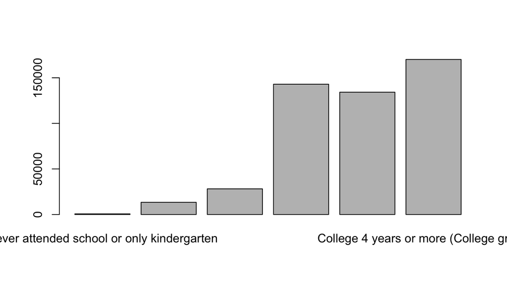

```r
plot(brfss2013$educa)
```

We can see that there are significantly more respondants who are high school and college graduates than the ones who are not. This poses a problem to generalise the conclusion for the groups of adults with some high school, elementary and no school levels.

```r
summary(brfss2013$genhlth)
```

```
## Excellent Very good      Good      Fair      Poor      NA's
##     85482    159076    150555     66726     27951      1985
```

```r
df1 <- brfss2013 %>%
  filter(!is.na(educa), !is.na(genhlth)) %>%
  select(genhlth, educa)

df1 %>%
  group_by(educa, genhlth) %>%
  summarise(count=n()) %>%
  mutate(proportion=count/sum(count))
```

```
## Source: local data frame [30 x 4]
## Groups: educa [6]
##
##                                         educa   genhlth count proportion
##                                        <fctr>    <fctr> <int>      <dbl>
## 1  Never attended school or only kindergarten Excellent    56 0.08536585
## 2  Never attended school or only kindergarten Very good    82 0.12500000
## 3  Never attended school or only kindergarten      Good   201 0.30640244
## 4  Never attended school or only kindergarten      Fair   199 0.30335366
## 5  Never attended school or only kindergarten      Poor   118 0.17987805
## 6             Grades 1 through 8 (Elementary) Excellent   900 0.06806322
## 7             Grades 1 through 8 (Elementary) Very good  1452 0.10980867
## 8             Grades 1 through 8 (Elementary)      Good  3972 0.30038569
## 9             Grades 1 through 8 (Elementary)      Fair  4383 0.33146790
## 10            Grades 1 through 8 (Elementary)      Poor  2516 0.19027452
## # ... with 20 more rows
```

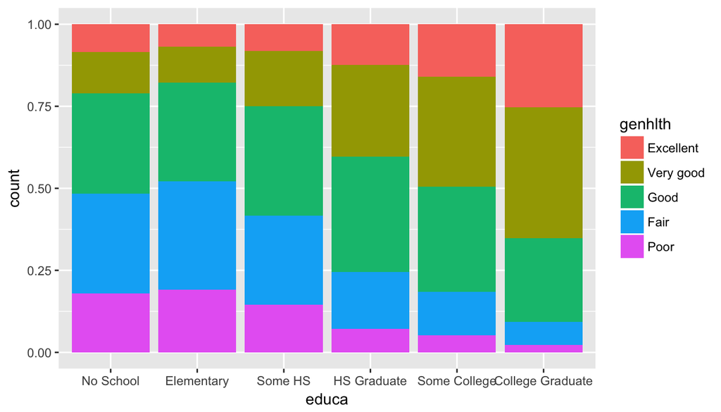

```r
ggplot(data=df1, aes(x=educa, fill=genhlth)) +
  geom_bar(position="fill") +
  scale_x_discrete(labels=c("No School", "Elementary", "Some HS", "HS Graduate", "Some College","College Graduate"))
```

The figure shows the positive relationship between educational levels and general health. The individuals with higher educational levels tend to be healthier than the ones with lower educational levels. As we can see at the college graduates, there is a small number of the poor general health status, which is approximately 2 percent of the group.

**Research quesion 2:**

The values are stored in a specific format. Theses values indicate how many days per week or per month did you have at least one drink of any alcoholic beverage during the past 30 days. The first digit denotes days per week (1) or days per month (2). The remaining digits indicate the count of days.

```r
table(brfss2013$alcday5)
```

```
##
##      0      1      2    101    102    103    104    105    106    107
## 236715      1      3  18241  14234   9684   4528   4625   1600  10153
##    201    202    203    204    205    206    207    208    209    210
##  38195  28772  16342  13170  13558   4861   3124   3784    297  10063
##    211    212    213    214    215    216    217    218    219    220
##     81   1900     77    610   7993    233     98    253     11   8119
##    221    222    223    224    225    226    227    228    229    230
##    190    161     93    186   3450    170    256   1014    354  14932
```

We also check the sex variable. There are more females than males in this sample.

```r
table(brfss2013$sex)
```

```
##
##   Male Female
## 201313 290455
```

```r
df2 <- brfss2013 %>%
  filter(!is.na(alcday5), !is.na(educa), !is.na(sex))
df2$drink <- ifelse(df2$alcday5 > 0, TRUE, FALSE)
```

We assign a new variable to indicate that if the number of alcohol drinks is greater than zero, this means they do drink - and vice versa.

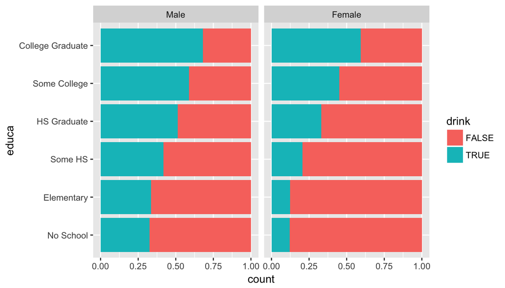

```r
ggplot(data=df2, aes(x=educa, fill=drink)) +
  geom_bar(position="fill") +
  facet_wrap(~sex) +
  scale_x_discrete(labels=c("No School", "Elementary", "Some HS", "HS Graduate", "Some College","College Graduate")) +
  coord_flip()
```

These plots show the positive link between education levels and alcohol consumption. This link also appears regardless of sex. However, women appear to consume less alcohol than men within the same education levels.

Let us transform data so we only have how many days per month did they have at least one drink of any alcoholic beverage during the past 30 days.

```r
df2 <- brfss2013 %>%
  filter(!is.na(alcday5), !is.na(educa), !is.na(sex))

df2$alcday5[(df2$alcday5>=100) & (df2$alcday5<200)] = (df2$alcday5[(df2$alcday5>=100) & (df2$alcday5<200)] - 100) * 4

df2$alcday5[(df2$alcday5>=200)] = (df2$alcday5[(df2$alcday5>=200) & (df2$alcday5<300)] - 200)

str(df2$alcday5)
```

```
##  num [1:470956] 1 0 20 8 10 0 1 2 4 0 ...
```

```r
summary(df2$alcday5)
```

```
##    Min. 1st Qu.  Median    Mean 3rd Qu.    Max.
##   0.000   0.000   0.000   4.589   5.000  30.000
```

We plot the transformed alcday5 values against educational levels.

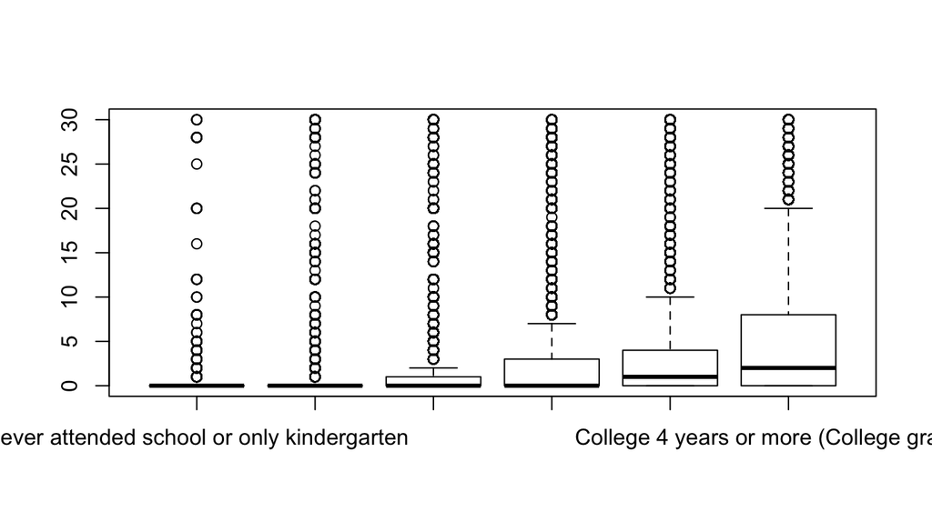

```r
plot(df2$educa, df2$alcday5)
```

From the plot, we can conclude that there is a positive relationship between education levels and alcohol consumption.

**Research quesion 3:**

X_smoker3 shows a computed smoking status consisting of four-level smoker statuses which are everyday smoker, someday smoker, former smoker, non-smoker.

```r
summary(brfss2013$X_smoker3)
```

```
## Current smoker - now smokes every day
##                                 55162
## Current smoker - now smokes some days
##                                 21495
##                         Former smoker
##                                138134
##                          Never smoked
##                                261651
##                                  NA's
##                                 15333
```

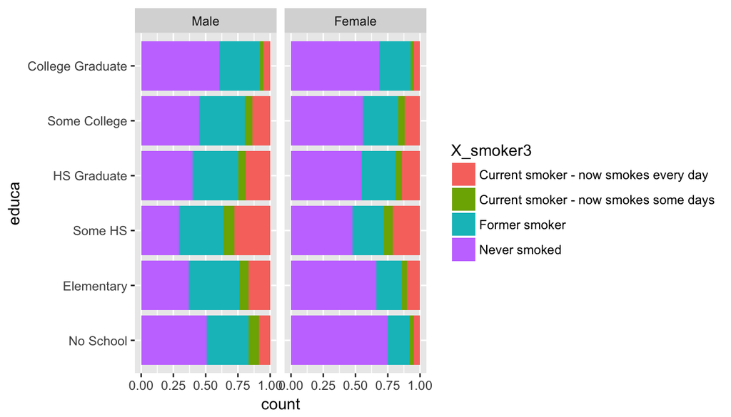

```r
df3 <- brfss2013 %>%
  filter(!is.na(educa), !is.na(X_smoker3), !is.na(sex)) %>%
  select(educa, X_smoker3, sex)

ggplot(data=df3, aes(x=educa, fill=X_smoker3)) +
  geom_bar(position="fill") +
  facet_wrap(~sex) +
  scale_x_discrete(labels=c("No School", "Elementary", "Some HS", "HS Graduate", "Some College","College Graduate")) +
  coord_flip()
```

These plots show interesting results if we compare them with the ones with alcohol consumption. Conversely, the relationship seems to be negative. The adults with higher education levels tend to smoke less than the ones with lower educational levels. There is an issue similarly to the previous research questions. Although, the adults with elementary and no school levels also appear to have less numbers of smokers but the sample sizes of these groups are significantly smaller than the other three groups which are college graduates, some colleges, and high school graduates. Therefore, we need more data to be able to fully conclude that there is a negative association between these two variables.